# Econometrics TP 2021-2022: OLS & IV Regression

Maria Teresa Aguilar Rojas

## Packages

```r
library(wooldridge) # To download database
library(tidyverse) # Tidyverse packages
library(stargazer) # To draw output tables
library(lmtest) # To test linear regression models
library(AER) # Contains some useful applied econometrics functions in R
```

## Data

We will use data from the following textbook: Wooldridge, Jeffrey M., 1960-. (2012). Introductory econometrics : a modern approach. Mason, Ohio: South-Western Cengage Learning

```r
data("wage2") # To load the data

head(wage2, n=20) # To check the 20 first entries of the database
```

|  | wage | hours | IQ | KWW | educ | exper | tenure | age | married | black | south | urban | sibs | brthord | meduc | feduc | lwage |
| --- | --- | --- | --- | --- | --- | --- | --- | --- | --- | --- | --- | --- | --- | --- | --- | --- | --- |
| 1 | 769 | 40 | 93 | 35 | 12 | 11 | 2 | 31 | 1 | 0 | 0 | 1 | 1 | 2 | 8 | 8 | 6.645091 |
| 2 | 808 | 50 | 119 | 41 | 18 | 11 | 16 | 37 | 1 | 0 | 0 | 1 | 1 | NA | 14 | 14 | 6.694562 |
| 3 | 825 | 40 | 108 | 46 | 14 | 11 | 9 | 33 | 1 | 0 | 0 | 1 | 1 | 2 | 14 | 14 | 6.715384 |
| 4 | 650 | 40 | 96 | 32 | 12 | 13 | 7 | 32 | 1 | 0 | 0 | 1 | 4 | 3 | 12 | 12 | 6.476973 |
| 5 | 562 | 40 | 74 | 27 | 11 | 14 | 5 | 34 | 1 | 0 | 0 | 1 | 10 | 6 | 6 | 11 | 6.331502 |
| 6 | 1400 | 40 | 116 | 43 | 16 | 14 | 2 | 35 | 1 | 1 | 0 | 1 | 1 | 2 | 8 | NA | 7.244227 |
| 7 | 600 | 40 | 91 | 24 | 10 | 13 | 0 | 30 | 0 | 0 | 0 | 1 | 1 | 2 | 8 | 8 | 6.396930 |
| 8 | 1081 | 40 | 114 | 50 | 18 | 8 | 14 | 38 | 1 | 0 | 0 | 1 | 2 | 3 | 8 | NA | 6.985642 |
| 9 | 1154 | 45 | 111 | 37 | 15 | 13 | 1 | 36 | 1 | 0 | 0 | 0 | 2 | 3 | 14 | 5 | 7.050990 |
| 10 | 1000 | 40 | 95 | 44 | 12 | 16 | 16 | 36 | 1 | 0 | 0 | 1 | 1 | 1 | 12 | 11 | 6.907755 |

[output cut: 10 more lines]

The description of the variables is as follow:

| Variable | Description |
| --- | --- |
| 1. wage | monthly earnings |
| 2. hours | average weekly hours |
| 3. IQ | IQ score |
| 4. KWW | knowledge of world work score |
| 5. educ | years of education |
| 6. exper | years of work experience |
| 7. tenure | years with current employer |
| 8. age | age in years |
| 9. married | =1 if married |
| 10. black | =1 if black |
| 11. south | =1 if live in south |
| 12. urban | =1 if live in SMSA |
| 13. sibs | number of siblings |
| 14. brthord | birth order |
| 15. meduc | mother’s education |
| 16. feduc | father’s education |
| 17. lwage | natural log of wage |

Before we start, let’s look at the summary of the data:

```r
summary(wage2)
```

```
##       wage            hours             IQ             KWW
##  Min.   : 115.0   Min.   :20.00   Min.   : 50.0   Min.   :12.00
##  1st Qu.: 669.0   1st Qu.:40.00   1st Qu.: 92.0   1st Qu.:31.00
##  Median : 905.0   Median :40.00   Median :102.0   Median :37.00
##  Mean   : 957.9   Mean   :43.93   Mean   :101.3   Mean   :35.74
##  3rd Qu.:1160.0   3rd Qu.:48.00   3rd Qu.:112.0   3rd Qu.:41.00
##  Max.   :3078.0   Max.   :80.00   Max.   :145.0   Max.   :56.00
##
##       educ           exper           tenure            age
##  Min.   : 9.00   Min.   : 1.00   Min.   : 0.000   Min.   :28.00
##  1st Qu.:12.00   1st Qu.: 8.00   1st Qu.: 3.000   1st Qu.:30.00
##  Median :12.00   Median :11.00   Median : 7.000   Median :33.00
##  Mean   :13.47   Mean   :11.56   Mean   : 7.234   Mean   :33.08
##  3rd Qu.:16.00   3rd Qu.:15.00   3rd Qu.:11.000   3rd Qu.:36.00
##  Max.   :18.00   Max.   :23.00   Max.   :22.000   Max.   :38.00
##
##     married          black            south            urban
##  Min.   :0.000   Min.   :0.0000   Min.   :0.0000   Min.   :0.0000
##  1st Qu.:1.000   1st Qu.:0.0000   1st Qu.:0.0000   1st Qu.:0.0000
##  Median :1.000   Median :0.0000   Median :0.0000   Median :1.0000
##  Mean   :0.893   Mean   :0.1283   Mean   :0.3412   Mean   :0.7176
##  3rd Qu.:1.000   3rd Qu.:0.0000   3rd Qu.:1.0000   3rd Qu.:1.0000
##  Max.   :1.000   Max.   :1.0000   Max.   :1.0000   Max.   :1.0000
##
##       sibs           brthord           meduc           feduc
##  Min.   : 0.000   Min.   : 1.000   Min.   : 0.00   Min.   : 0.00
##  1st Qu.: 1.000   1st Qu.: 1.000   1st Qu.: 8.00   1st Qu.: 8.00
##  Median : 2.000   Median : 2.000   Median :12.00   Median :10.00
##  Mean   : 2.941   Mean   : 2.277   Mean   :10.68   Mean   :10.22
##  3rd Qu.: 4.000   3rd Qu.: 3.000   3rd Qu.:12.00   3rd Qu.:12.00
##  Max.   :14.000   Max.   :10.000   Max.   :18.00   Max.   :18.00
##                   NA's   :83       NA's   :78      NA's   :194
##      lwage
##  Min.   :4.745
##  1st Qu.:6.506
##  Median :6.808
##  Mean   :6.779
##  3rd Qu.:7.056
##  Max.   :8.032
##
```

## Descriptive statistics

**1.** Find the average education level in the sample. What are the lowest and highest years of education?

```r
summary(wage2$educ)
```

```
##    Min. 1st Qu.  Median    Mean 3rd Qu.    Max.
##    9.00   12.00   12.00   13.47   16.00   18.00
```

The average education level in the sample is 13.47 years. The lowest corresponds to 9 years of education and the highest is 18 years of education.

**2.** How many people live in urban areas? how many people live in rural areas?

```r
table(wage2$urban)
```

```
##
##   0   1
## 264 671
```

Out of 935 people in our sample, 671 live in urban areas, while 264 live in rural areas.

**3.** How many people live in urban areas and are married?

```r
# Option 1
table(wage2$married, wage2$urban, dnn = c("married", "urban")) # To calculate a cross tabulation
```

```
##        urban
## married   0   1
##       0  23  77
##       1 241 594
```

```r
# Option 2: Tidyverse syntax
wage2 %>%
  count(married, urban)
```

| married | urban | n |
| --- | --- | --- |
| 0 | 0 | 23 |
| 0 | 1 | 77 |
| 1 | 0 | 241 |
| 1 | 1 | 594 |

Out of 935 people in our sample, 594 live in urban areas and are married.

**4.** What is the average wage for married people?

```r
# Option 1
aggregate(wage~married, data = wage2, FUN=mean)
```

| married | wage |
| --- | --- |
| 0 | 798.4400 |
| 1 | 977.0479 |

```r
# Option 2: Tidyverse syntax
wage2 %>%
  group_by(married) %>%
  summarise(mean(wage))
```

| married | mean(wage) |
| --- | --- |
| 0 | 798.4400 |
| 1 | 977.0479 |

The average wage for married people is of 977.0479 dollars.

**5.** What is the correlation between wage and education? Is this correlation significant?

```r
cor(wage2$wage, wage2$educ)
```

```
## [1] 0.3271087
```

The correlation between wage and education is of 0.3271087.

To test if the correlation is significant:

```r
cor.test(wage2$wage, wage2$educ)
```

```
##
##  Pearson's product-moment correlation
##
## data:  wage2$wage and wage2$educ
## t = 10.573, df = 933, p-value < 2.2e-16
## alternative hypothesis: true correlation is not equal to 0
## 95 percent confidence interval:
##  0.2686296 0.3831853
## sample estimates:
##       cor
## 0.3271087
```

Yes, the correlation is significant (p-value < 2.2e-16).

**6.** Get the correlation table for all the variables of the dataset

```r
stargazer(cor(wage2), type = "text")
```

```
##
## ==============================================================================================================================
##          wage  hours    IQ    KWW    educ  exper  tenure  age   married black  south  urban   sibs  brthord meduc feduc lwage
## ------------------------------------------------------------------------------------------------------------------------------
## wage      1    -0.010 0.309  0.326  0.327  0.002  0.128  0.157   0.137  -0.211 -0.159 0.198  -0.159                     0.953
## hours   -0.010   1    0.074  0.114  0.091  -0.062 -0.056 0.025   0.033  -0.108 -0.030 0.017  -0.050                     -0.047
## IQ      0.309  0.074    1    0.414  0.516  -0.225 0.042  -0.044 -0.015  -0.388 -0.210 0.039  -0.285                     0.315
## KWW     0.326  0.114  0.414    1    0.388  0.017  0.141  0.393   0.090  -0.281 -0.094 0.098  -0.285                     0.306
## educ    0.327  0.091  0.516  0.388    1    -0.456 -0.036 -0.012 -0.059  -0.179 -0.097 0.072  -0.239                     0.312
## exper   0.002  -0.062 -0.225 0.017  -0.456   1    0.244  0.495   0.106  0.056  0.021  -0.047 0.064                      0.021
## tenure  0.128  -0.056 0.042  0.141  -0.036 0.244    1    0.271   0.073  -0.078 -0.062 -0.038 -0.039                     0.186
## age     0.157  0.025  -0.044 0.393  -0.012 0.495  0.271    1     0.107  -0.036 -0.029 -0.007 -0.041                     0.162
## married 0.137  0.033  -0.015 0.090  -0.059 0.106  0.073  0.107     1    -0.053 0.023  -0.040 -0.004                     0.150
## black   -0.211 -0.108 -0.388 -0.281 -0.179 0.056  -0.078 -0.036 -0.053    1    0.236  0.070  0.305                      -0.232
## south   -0.159 -0.030 -0.210 -0.094 -0.097 0.021  -0.062 -0.029  0.023  0.236    1    -0.110 0.066                      -0.195
## urban   0.198  0.017  0.039  0.098  0.072  -0.047 -0.038 -0.007 -0.040  0.070  -0.110   1    -0.031                     0.204
## sibs    -0.159 -0.050 -0.285 -0.285 -0.239 0.064  -0.039 -0.041 -0.004  0.305  0.066  -0.031   1                        -0.153
## brthord                                                                                                1
## meduc                                                                                                         1
## feduc                                                                                                               1
## lwage   0.953  -0.047 0.315  0.306  0.312  0.021  0.186  0.162   0.150  -0.232 -0.195 0.204  -0.153                       1
## ------------------------------------------------------------------------------------------------------------------------------
```

**7.** Find the average salary and average IQ in the sample. what is the sample standard deviation of IQ? (IQ scores are standardized so that the average in the population is 100 with a SD equal to 15)

```r
# Method 1 : Basic R syntax
mean(wage2$IQ)
```

```
## [1] 101.2824
```

```r
mean(wage2$wage)
```

```
## [1] 957.9455
```

```r
sd(wage2$IQ)
```

```
## [1] 15.05264
```

```r
# Method 2: Tidyverse syntax
 wage2 %>%
  summarise(
    mean_IQ = mean(IQ),
    mean_wage = mean(wage),
    sd_IQ = sd(IQ),
    count = n()
    )
```

| mean_IQ | mean_wage | sd_IQ | count |
| --- | --- | --- | --- |
| 101.2824 | 957.9455 | 15.05264 | 935 |

## OLS Regression

**8.** Estimate the simple regression model where a one-point increase in IQ changes wage by a constant dollar amount. use this model to find the predicted increase in wage for an increase in IQ of 15 points. Does IQ explain most of the variation in wage?

```r
m1 <- lm(wage ~ IQ, data = wage2)

#option 1: Basic R syntax to how regression results
summary(m1)
```

```
##
## Call:
## lm(formula = wage ~ IQ, data = wage2)
##
## Residuals:
##    Min     1Q Median     3Q    Max
## -898.7 -256.5  -47.3  201.1 2072.6
##
## Coefficients:
##             Estimate Std. Error t value Pr(>|t|)
## (Intercept) 116.9916    85.6415   1.366    0.172
## IQ            8.3031     0.8364   9.927   <2e-16 ***
## ---
## Signif. codes:  0 '***' 0.001 '**' 0.01 '*' 0.05 '.' 0.1 ' ' 1
##
## Residual standard error: 384.8 on 933 degrees of freedom
## Multiple R-squared:  0.09554,    Adjusted R-squared:  0.09457
## F-statistic: 98.55 on 1 and 933 DF,  p-value: < 2.2e-16
```

```r
#Option 2: Show the regression results with stargarzer package
stargazer(m1, type = "text")
```

```
##
## ===============================================
##                         Dependent variable:
##                     ---------------------------
##                                wage
## -----------------------------------------------
## IQ                           8.303***
##                               (0.836)
##
## Constant                      116.992
##                              (85.642)
##
## -----------------------------------------------
## Observations                    935
## R2                             0.096
## Adjusted R2                    0.095
## Residual Std. Error     384.767 (df = 933)
## F Statistic           98.549*** (df = 1; 933)
## ===============================================
## Note:               *p<0.1; **p<0.05; ***p<0.01
```

```r
m1$coefficients["IQ"]
```

```
##       IQ
## 8.303064
```

```r
15*8.303 # 124.5 dollars increase in wage for an increase in IQ of 15 points
```

```
## [1] 124.545
```

The predicted increase in wage for an increase in IQ of 15 points is of 124.5 dollars. IQ does not explain most of the variation in wage ($R^2 = 9.6$). However, this does not imply that the variable is non-important!

**9.** Now estimate a model where each one-point increase in IQ has the same percentage effect on wage. If IQ increases by 15 points, what is the approximate percentage increase in predicted wage?

```r
wage2$lwage <- log(wage2$wage)

m2 <- lm(lwage ~ IQ, data = wage2)


stargazer(m2, type = 'text')
```

```
##
## ===============================================
##                         Dependent variable:
##                     ---------------------------
##                                lwage
## -----------------------------------------------
## IQ                           0.009***
##                               (0.001)
##
## Constant                     5.887***
##                               (0.089)
##
## -----------------------------------------------
## Observations                    935
## R2                             0.099
## Adjusted R2                    0.098
## Residual Std. Error      0.400 (df = 933)
## F Statistic          102.621*** (df = 1; 933)
## ===============================================
## Note:               *p<0.1; **p<0.05; ***p<0.01
```

```r
0.9*15
```

```
## [1] 13.5
```

The percentage increase in predicted wage for an increase in IQ of 15 points is of 13.5%.

Remark: You can check the table in the following link, to better understand the interpretation of the beta coefficients, according to the model https://sites.google.com/site/curtiskephart/ta/econ113/interpreting-beta

**10.** Estimate the following model:

$log(wage) = \beta_0 + \beta_1 IQ + \beta_2 educ + \beta_3 exper + \beta_4 black + \beta_5 tenure + \beta_6 married + \beta_7 south$

```r
m3 <- lm(lwage ~ IQ + educ + exper + black + tenure + married + south, data = wage2)

stargazer(m3, type = 'text')
```

```
##
## ===============================================
##                         Dependent variable:
##                     ---------------------------
##                                lwage
## -----------------------------------------------
## IQ                           0.004***
##                               (0.001)
##
## educ                         0.057***
##                               (0.007)
##
## exper                        0.014***
##                               (0.003)
##
## black                        -0.114***
##                               (0.040)
##
## tenure                       0.011***
##                               (0.002)
##
## married                      0.193***
##                               (0.040)
##
## south                        -0.102***
##                               (0.027)
##
## Constant                     5.277***
##                               (0.130)
##
## -----------------------------------------------
## Observations                    935
## R2                             0.226
## Adjusted R2                    0.220
## Residual Std. Error      0.372 (df = 927)
## F Statistic           38.689*** (df = 7; 927)
## ===============================================
## Note:               *p<0.1; **p<0.05; ***p<0.01
```

**11.** What is the interpretation of $\beta_2$? and of $\beta_4$?

- $\beta_2$ : One year more of education increases predicted wage by 5.7%.
- $\beta_4$ : The average wage difference between black and non-black people is of -11.4%. Then, black people earn 11.4% less than non-black people.

**12.** Consider the following model:

$log(wage) = \beta_0 + \beta_1 educ + \beta_2 exper + \beta_3 tenure + u$

1. State the null hypothesis that another year of general workforce experience has the same effect on log wage as another year of tenure with the current employer.
2. Test the null hypothesis against a two sided alternative at the 5% significance level, by constructing a 95% confidence interval. What do you conclude?

*Solutions*

1. The null hypothesis of interest is $H_0: \beta_2 = \beta_3$.
2. Let $\theta_2 = \beta_2 - \beta_3$. We replace $\beta_2$ in the initial model, which gives:

Step 1: $\theta_2 + \beta_3 = \beta_2$

Step2: $log(wage) = \beta_0 + \beta_1 educ + (\theta_2 + \beta_3) exper + \beta_3 tenure + u$

Step3: $log(wage) = \beta_0 + \beta_1 educ + \theta_2exper + \beta_3exper + \beta_3 tenure + u$

After replacement, our model is as follows:

$log(wage) = \beta_0 + \beta_1 educ + \theta_2 exper + \beta_3(exper + tenure) + u$

```r
wage2 <- wage2 %>%
  mutate(exper_tenure = exper+tenure)


m4 <- lm(lwage ~ educ + exper + exper_tenure, data = wage2)
summary(m4)
```

```
##
## Call:
## lm(formula = lwage ~ educ + exper + exper_tenure, data = wage2)
##
## Residuals:
##     Min      1Q  Median      3Q     Max
## -1.8282 -0.2401  0.0203  0.2569  1.3400
##
## Coefficients:
##              Estimate Std. Error t value Pr(>|t|)
## (Intercept)  5.496696   0.110528  49.731  < 2e-16 ***
## educ         0.074864   0.006512  11.495  < 2e-16 ***
## exper        0.001954   0.004743   0.412    0.681
## exper_tenure 0.013375   0.002587   5.170 2.87e-07 ***
## ---
## Signif. codes:  0 '***' 0.001 '**' 0.01 '*' 0.05 '.' 0.1 ' ' 1
##
## Residual standard error: 0.3877 on 931 degrees of freedom
## Multiple R-squared:  0.1551, Adjusted R-squared:  0.1524
## F-statistic: 56.97 on 3 and 931 DF,  p-value: < 2.2e-16
```

```r
stargazer(m4, type = 'text')
```

```
##
## ===============================================
##                         Dependent variable:
##                     ---------------------------
##                                lwage
## -----------------------------------------------
## educ                         0.075***
##                               (0.007)
##
## exper                          0.002
##                               (0.005)
##
## exper_tenure                 0.013***
##                               (0.003)
##
## Constant                     5.497***
##                               (0.111)
##
## -----------------------------------------------
## Observations                    935
## R2                             0.155
## Adjusted R2                    0.152
## Residual Std. Error      0.388 (df = 931)
## F Statistic           56.974*** (df = 3; 931)
## ===============================================
## Note:               *p<0.1; **p<0.05; ***p<0.01
```

This turns out to be about 0.002 ± 1.96(.0047), or about -.0072 to .0112. Because zero is in this CI, $\theta_2$ is not statistically different from zero at the 5% level, and we fail to reject $H_0: \beta_2 = \beta_3$ at the 5% level.

**13.** Use OLS to estimate the following equation:

$log(wage) = \beta_0 + \beta_1 educ + \beta_2 exper + \beta_3 educ^2 + u$

1. Is $educ^2$ statistically significant at a 10% level? at a 5% level? at a 1% level?
2. How can we interpret $\beta_3$?
3. What is the return to the 5th year of education?

*Solutions*

```r
wage2 <- wage2 %>% mutate(educ2 = educ*educ)
m5 <- lm(lwage ~ educ + exper + educ2, data = wage2)
stargazer(m5, type = 'text')
```

```
##
## ===============================================
##                         Dependent variable:
##                     ---------------------------
##                                lwage
## -----------------------------------------------
## educ                         0.226***
##                               (0.078)
##
## exper                        0.021***
##                               (0.003)
##
## educ2                         -0.005*
##                               (0.003)
##
## Constant                     4.473***
##                               (0.553)
##
## -----------------------------------------------
## Observations                    935
## R2                             0.134
## Adjusted R2                    0.131
## Residual Std. Error      0.392 (df = 931)
## F Statistic           48.110*** (df = 3; 931)
## ===============================================
## Note:               *p<0.1; **p<0.05; ***p<0.01
```

$educ^2$ is statistically significant at a 10% level, but not at a 5% or 1% level. $_3 = -0.005 $, this implies educ has a diminishing effect on wage.

The first year, the return to education is 22.6%. The fifth year, it is: $\% \Delta \hat{wage} \approx 100[0.226 - 2(0.005)(5)]$

```r
 100*(0.226 - 2*(0.005*5))
```

```
## [1] 17.6
```

**14.** Consider a model:

$log(wage) = \beta_0 + \beta_1 educ + \beta_2 exper + \beta_3 educ*exper + u$

1. State the null hypothesis that the return to education does not depend on the level of exper. What do you think is the appropriate alternative?
2. Test the null hypothesis in (ii) against your stated alternative.
3. Interpret $\beta_3$.

*Solutions*

1. $H_0 = \beta_3$. If we think that education and experience interact positively – so that people with more experience are more productive when given another year of education – then $\beta_3 > 0$ is the appropriate alternative.

(ii)

```r
wage2 <- wage2 %>% mutate(educ_exper = educ*exper)

m6 <- lm(lwage ~ educ + exper + educ_exper, data = wage2)
stargazer(m6, type = 'text')
```

```
##
## ===============================================
##                         Dependent variable:
##                     ---------------------------
##                                lwage
## -----------------------------------------------
## educ                          0.044**
##                               (0.017)
##
## exper                         -0.021
##                               (0.020)
##
## educ_exper                    0.003**
##                               (0.002)
##
## Constant                     5.949***
##                               (0.241)
##
## -----------------------------------------------
## Observations                    935
## R2                             0.135
## Adjusted R2                    0.132
## Residual Std. Error      0.392 (df = 931)
## F Statistic           48.407*** (df = 3; 931)
## ===============================================
## Note:               *p<0.1; **p<0.05; ***p<0.01
```

```r
linearHypothesis(m6, "educ_exper=0", type=c("t"))
```

|  | Res.Df | RSS | Df | Sum of Sq | F | Pr(>F) |
| --- | --- | --- | --- | --- | --- | --- |
| 1 | 932 | 143.9786 | NA | NA | NA | NA |
| 2 | 931 | 143.3033 | 1 | 0.6753133 | 4.387314 | 0.03647711 |

(iii) People with more experience are more productive when given another year of education by 0.3%

*Note: heteroskedasticity happens when the standard deviations of a predicted variable, monitored over different values of an independent variable or as related to prior time periods, are non-constant.*

```r
# Breusch-Pagan test for Heteroskedasticity
bptest(m3)
```

```
##
##  studentized Breusch-Pagan test
##
## data:  m3
## BP = 27.278, df = 7, p-value = 0.000297
```

```r
# Robust SE
coeftest(m3, vcovHC)
```

```
##
## t test of coefficients:
##
##                Estimate  Std. Error t value  Pr(>|t|)
## (Intercept)  5.27655494  0.12544761 42.0618 < 2.2e-16 ***
## IQ           0.00369681  0.00099216  3.7260 0.0002063 ***
## educ         0.05673191  0.00746601  7.5987 7.309e-14 ***
## exper        0.01401967  0.00329844  4.2504 2.350e-05 ***
## black       -0.11424608  0.03796320 -3.0094 0.0026886 **
## tenure       0.01086909  0.00259212  4.1931 3.015e-05 ***
## married      0.19341995  0.04079979  4.7407 2.464e-06 ***
## south       -0.10224056  0.02802988 -3.6476 0.0002795 ***
## ---
## Signif. codes:  0 '***' 0.001 '**' 0.01 '*' 0.05 '.' 0.1 ' ' 1
```

```r
stargazer(coeftest(m3, vcovHC), type ='text')
```

```
##
## ====================================
##              Dependent variable:
##          ---------------------------
##
## ------------------------------------
## IQ                0.004***
##                    (0.001)
##
## educ              0.057***
##                    (0.007)
##
## exper             0.014***
##                    (0.003)
##
## black             -0.114***
##                    (0.038)
##
## tenure            0.011***
##                    (0.003)
##
## married           0.193***
##                    (0.041)
##
## south             -0.102***
##                    (0.028)
##
## Constant          5.277***
##                    (0.125)
##
## ====================================
## ====================================
## Note:    *p<0.1; **p<0.05; ***p<0.01
```

## Plots

**16** Draw a plot of predicted wage with respect to IQ

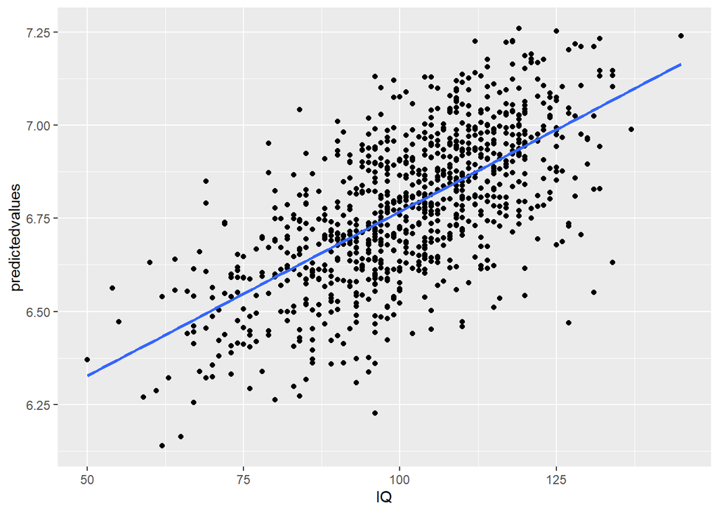

```r
predictedvalues <- predict(m3)
res <- residuals(m3)

wage2 %>% ggplot(aes(x = IQ, y = predictedvalues)) +
     geom_point() +
     geom_smooth(method = "lm", se = FALSE)
```

**17** Draw a plot of predicted wage with respect to education

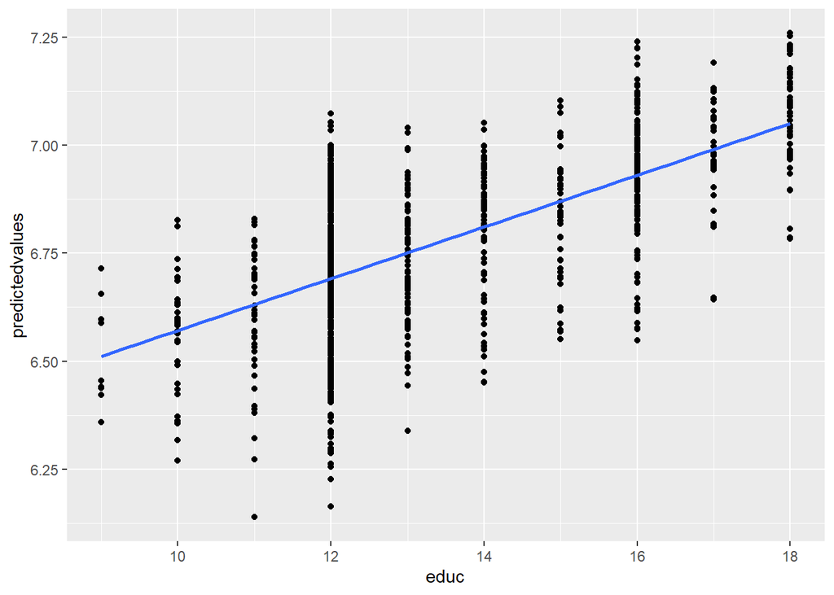

```r
wage2 %>%
  ggplot(aes(x = educ, y = predictedvalues)) +
  geom_point() +
  geom_smooth(method = "lm", se = FALSE)
```

**18** Draw a plot of the residuals with respect to IQ. Only looking at the graph, can you spot for the presence of heteroskedasticity?

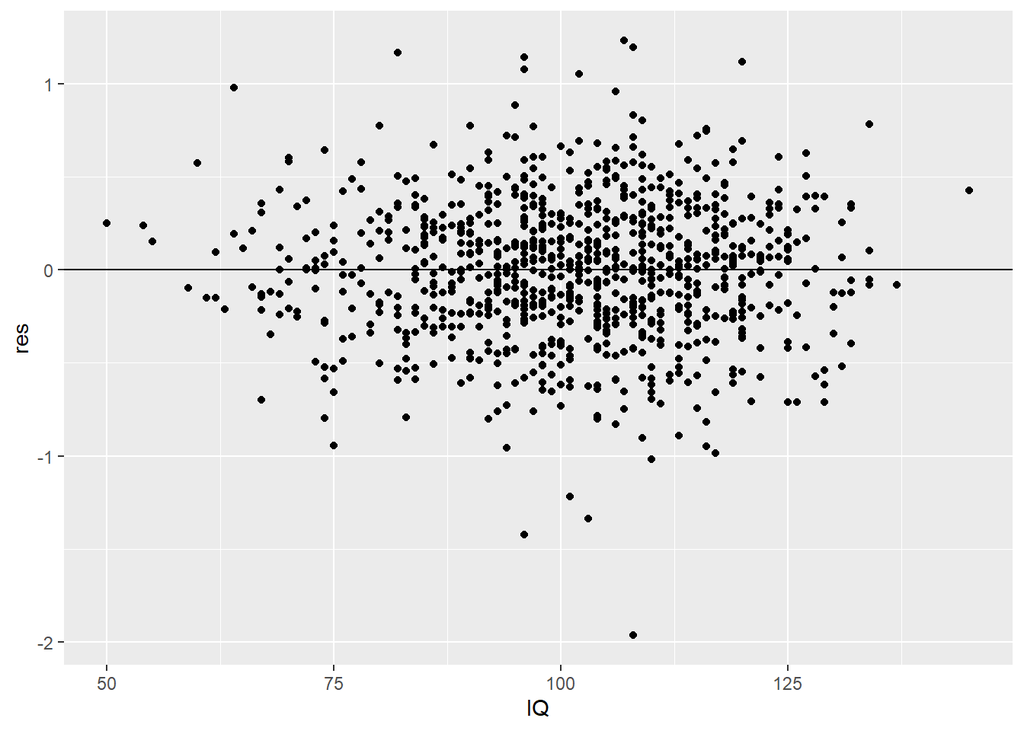

```r
# Check for heteroskedasticity
wage2 %>%
  ggplot(aes(x = IQ, y = res)) +
  geom_point() +
  geom_hline(aes(yintercept=mean(res)))
```

## IV

We use data *wage2* to estimate the return to education for men.

**19** Run the model that estimates the return to education for men

We estimate the following model:

$log(wage) = \beta_0 + \beta_1 educ + u$

```r
model <- lm(lwage ~ educ, data = wage2)
summary(model)
```

```
##
## Call:
## lm(formula = lwage ~ educ, data = wage2)
##
## Residuals:
##      Min       1Q   Median       3Q      Max
## -1.94620 -0.24832  0.03507  0.27440  1.28106
##
## Coefficients:
##             Estimate Std. Error t value Pr(>|t|)
## (Intercept) 5.973062   0.081374   73.40   <2e-16 ***
## educ        0.059839   0.005963   10.04   <2e-16 ***
## ---
## Signif. codes:  0 '***' 0.001 '**' 0.01 '*' 0.05 '.' 0.1 ' ' 1
##
## Residual standard error: 0.4003 on 933 degrees of freedom
## Multiple R-squared:  0.09742,    Adjusted R-squared:  0.09645
## F-statistic: 100.7 on 1 and 933 DF,  p-value: < 2.2e-16
```

**2.** Is there a possible endogeneity in one of the variables of the model? If so, why? what type of endogeneity do you encounter?

One of the variables is endogenous (not randomly assigned). Education is an endogenous variable. For example, parents income is going to be related to the choice of education of the kid. In this case, the type of endogeneity is the omitted variable bias.

**3.** Suppose we choose the variable `sibs` (number of siblings) as an instrument to correct for the endogeneity in the initial model. For this instrument:

1. Do the first stage regression of the IV on the endogenous variable

```r
# Let's look at first stage
fs1 <- lm(educ ~ sibs, data = wage2)
summary(fs1)
```

```
##
## Call:
## lm(formula = educ ~ sibs, data = wage2)
##
## Residuals:
##    Min     1Q Median     3Q    Max
## -5.139 -1.683 -0.683  1.931  6.140
##
## Coefficients:
##             Estimate Std. Error t value Pr(>|t|)
## (Intercept) 14.13879    0.11314 124.969  < 2e-16 ***
## sibs        -0.22792    0.03028  -7.528 1.22e-13 ***
## ---
## Signif. codes:  0 '***' 0.001 '**' 0.01 '*' 0.05 '.' 0.1 ' ' 1
##
## Residual standard error: 2.134 on 933 degrees of freedom
## Multiple R-squared:  0.05726,    Adjusted R-squared:  0.05625
## F-statistic: 56.67 on 1 and 933 DF,  p-value: 1.215e-13
```

```r
# F test of coefficient on the instrument
linearHypothesis(fs1, "sibs=0", type=c("F"))
```

|  | Res.Df | RSS | Df | Sum of Sq | F | Pr(>F) |
| --- | --- | --- | --- | --- | --- | --- |
| 1 | 934 | 4506.819 | NA | NA | NA | NA |
| 2 | 933 | 4248.764 | 1 | 258.055 | 56.66715 | 1.215402e-13 |

2. Is the instrument correlated with the endogenous variable? What is the sense of this correlation? Explain.

Yes, the IV `sibs` is **negatively** correlated with the endogenous variable `educ`. According to the first stage regression of `sibs` on `educ`, the coefficient of `sibs` is equal to -0.227. This coefficient is significant at a 1% level.

The correlation coefficient is used to measure the strength of the linear relationship between two variables. For our case, this means that men with more siblings attain less years of education.

*Remark:* A suitable IV must be correlated with the endogenous variable.

3. Argue if it is exogenous.

`sibs` is probably not exogenous. It might be correlated with some socio-economic characteristics that influence wage, such as the family background.

**4.** Run the 2SLS model, using `sibs` as an IV for `educ`

1. Using the function ivreg in R

```r
# Perform an instrumental variable's regression
ivmodel <- ivreg(lwage ~ educ | sibs,data = wage2)

summary(ivmodel)
```

```
##
## Call:
## ivreg(formula = lwage ~ educ | sibs, data = wage2)
##
## Residuals:
##      Min       1Q   Median       3Q      Max
## -1.85429 -0.26950  0.04223  0.29276  1.31039
##
## Coefficients:
##             Estimate Std. Error t value Pr(>|t|)
## (Intercept)  5.13003    0.35517  14.444  < 2e-16 ***
## educ         0.12243    0.02635   4.646 3.86e-06 ***
## ---
## Signif. codes:  0 '***' 0.001 '**' 0.01 '*' 0.05 '.' 0.1 ' ' 1
##
## Residual standard error: 0.4233 on 933 degrees of freedom
## Multiple R-Squared: -0.009174,   Adjusted R-squared: -0.01026
## Wald test: 21.59 on 1 and 933 DF,  p-value: 3.865e-06
```

(ii) Manually

```r
summary(lm(lwage ~ fs1$fitted.values, data = wage2))
```

```
##
## Call:
## lm(formula = lwage ~ fs1$fitted.values, data = wage2)
##
## Residuals:
##      Min       1Q   Median       3Q      Max
## -1.97662 -0.25857  0.02503  0.28572  1.22677
##
## Coefficients:
##                   Estimate Std. Error t value Pr(>|t|)
## (Intercept)        5.13003    0.34940  14.682  < 2e-16 ***
## fs1$fitted.values  0.12243    0.02592   4.723 2.68e-06 ***
## ---
## Signif. codes:  0 '***' 0.001 '**' 0.01 '*' 0.05 '.' 0.1 ' ' 1
##
## Residual standard error: 0.4164 on 933 degrees of freedom
## Multiple R-squared:  0.02335,    Adjusted R-squared:  0.0223
## F-statistic: 22.31 on 1 and 933 DF,  p-value: 2.68e-06
```

Same results as with ivreg, but SEs slightly different.

**5.** To convince yourself that using `sibs` as an IV for educ is not the same as just plugging `sibs` for educ and running an OLS regression, run the regression of log(wage) on `sibs` and explain your findings.

```r
summary(lm(lwage ~ sibs, data = wage2))
```

```
##
## Call:
## lm(formula = lwage ~ sibs, data = wage2)
##
## Residuals:
##      Min       1Q   Median       3Q      Max
## -1.97662 -0.25857  0.02503  0.28572  1.22677
##
## Coefficients:
##              Estimate Std. Error t value Pr(>|t|)
## (Intercept)  6.861076   0.022078 310.771  < 2e-16 ***
## sibs        -0.027904   0.005908  -4.723 2.68e-06 ***
## ---
## Signif. codes:  0 '***' 0.001 '**' 0.01 '*' 0.05 '.' 0.1 ' ' 1
##
## Residual standard error: 0.4164 on 933 degrees of freedom
## Multiple R-squared:  0.02335,    Adjusted R-squared:  0.0223
## F-statistic: 22.31 on 1 and 933 DF,  p-value: 2.68e-06
```

This is a reduced form simple regression equation. It shows that, controlling for no other factors, one more sibling in the family is associated with monthly salary that is about 2.8% lower. The t statistic on `sibs` is about –4.73. Of course `sibs` can be correlated with many things that should have a bearing on wage including, as we already saw, years of education.

**6.** The variable `brthord` is birth order (`brthord` is one for the first-born child, two for a second-born child, and so on). Explain why `educ` and `brthord` might be negatively correlated.

It could be that older children are given priority for higher education, and families may hit budget constraints and may not be able to afford as much education for children born later.

**7.** Regress `educ` on `brthord` to determine whether there is a statistically significant negative correlation.

The simple regression of educ on brthord gives

```r
fs2 <- lm(educ ~ brthord, data = wage2)
summary(fs2)
```

```
##
## Call:
## lm(formula = educ ~ brthord, data = wage2)
##
## Residuals:
##     Min      1Q  Median      3Q     Max
## -4.8668 -1.5842 -0.7362  2.1332  6.1117
##
## Coefficients:
##             Estimate Std. Error t value Pr(>|t|)
## (Intercept) 14.14945    0.12868 109.962  < 2e-16 ***
## brthord     -0.28264    0.04629  -6.106 1.55e-09 ***
## ---
## Signif. codes:  0 '***' 0.001 '**' 0.01 '*' 0.05 '.' 0.1 ' ' 1
##
## Residual standard error: 2.155 on 850 degrees of freedom
##   (83 observations effacées parce que manquantes)
## Multiple R-squared:  0.04202,    Adjusted R-squared:  0.04089
## F-statistic: 37.29 on 1 and 850 DF,  p-value: 1.551e-09
```

```r
# F test of coefficient on the instrument
linearHypothesis(fs2, "brthord=0", type=c("F"))
```

|  | Res.Df | RSS | Df | Sum of Sq | F | Pr(>F) |
| --- | --- | --- | --- | --- | --- | --- |
| 1 | 851 | 4118.971 | NA | NA | NA | NA |
| 2 | 850 | 3945.884 | 1 | 173.087 | 37.28543 | 1.550792e-09 |

(Note that `brthord` is missing for 83 observations.) The equation predicts that every one-unit increase in `brthord` reduces predicted education by about 0.28 years.

**8.** What is the difference in predicted education for a first-born and a fourth born child?

```r
preduc1 <- fs2$coefficients[["brthord"]]

preduc4 <- fs2$coefficients[["brthord"]]*4

preduc1 - preduc4 #difference in predicted education for a first-born an fourth born child
```

```
## [1] 0.8479324
```

The difference in predicted education for a first-born and fourth-born child is about 0.85 years.

**9.** Use `brthord` as an IV for `educ`. Report and interpret the results. Report and interpret the results.

```r
ivmodel2 <- ivreg(lwage ~ educ | brthord, data = wage2)
summary(ivmodel2)
```

```
##
## Call:
## ivreg(formula = lwage ~ educ | brthord, data = wage2)
##
## Residuals:
##     Min      1Q  Median      3Q     Max
## -1.8532 -0.2557  0.0435  0.2970  1.3033
##
## Coefficients:
##             Estimate Std. Error t value Pr(>|t|)
## (Intercept)  5.03040    0.43295  11.619  < 2e-16 ***
## educ         0.13064    0.03204   4.078 4.97e-05 ***
## ---
## Signif. codes:  0 '***' 0.001 '**' 0.01 '*' 0.05 '.' 0.1 ' ' 1
##
## Residual standard error: 0.4215 on 850 degrees of freedom
## Multiple R-Squared: -0.02862,    Adjusted R-squared: -0.02983
## Wald test: 16.63 on 1 and 850 DF,  p-value: 4.975e-05
```

(The R-squared is negative.) This is much higher than the OLS estimate (.060) and even above the estimate when `sibs` is used as an IV for educ (.122). Because of missing data on brthord, we are using fewer observations than in the previous analyses.

$R^2$ compares the fit of the chosen model with that of a horizontal straight line (the null hypothesis). If the chosen model fits worse than a horizontal line, then R2 is negative.

**10.** Now, suppose that we include number of siblings as an explanatory variable in the wage equation; this controls for family background, to some extent:

$log(wage) = \beta_0 + \beta_1 educ + \beta_2 sibs + u$

Suppose that we want to use `brthord` as an IV for `educ`, assuming that `sibs` is exogenous. The reduced form for `educ` is

$educ= \pi_0 + \pi_1 sibs + \pi_2 brthord + v$

1. State and test the identification assumption.

```r
fs3 <- lm(educ ~ sibs + brthord, data = wage2)

summary(fs3)
```

```
##
## Call:
## lm(formula = educ ~ sibs + brthord, data = wage2)
##
## Residuals:
##     Min      1Q  Median      3Q     Max
## -5.1438 -1.6854 -0.6852  2.0090  5.9950
##
## Coefficients:
##             Estimate Std. Error t value Pr(>|t|)
## (Intercept) 14.29650    0.13329 107.260  < 2e-16 ***
## sibs        -0.15287    0.03987  -3.834 0.000135 ***
## brthord     -0.15267    0.05708  -2.675 0.007619 **
## ---
## Signif. codes:  0 '***' 0.001 '**' 0.01 '*' 0.05 '.' 0.1 ' ' 1
##
## Residual standard error: 2.137 on 849 degrees of freedom
##   (83 observations effacées parce que manquantes)
## Multiple R-squared:  0.05833,    Adjusted R-squared:  0.05611
## F-statistic: 26.29 on 2 and 849 DF,  p-value: 8.33e-12
```

We need $\pi_2 \neq 0$ in order for the $\beta_j$ to be identified. We take the null to be $H_0: \pi = 0$, and look to reject $H_0$ at a small significance level. The regression of educ on sibs and brthord (using 852 observations) yields $\hat\pi_2 = −0.153$ and $se(\hat\pi_2) = 0.057$. The t statistic is about –2.68, and p-value is about 0.007 which rejects $H_0$ fairly strongly. Therefore, the identification assumptions appears to hold.

2. Estimate the previous equation using `brthord` as an IV for educ (and `sibs` as its own IV). Comment on the standard errors for $\beta_{educ}$ and $\beta_{sibs}$

```r
ivmodel3 <- ivreg(log(wage) ~ educ + sibs | brthord + sibs, data = wage2)
summary(ivmodel3)
```

```
##
## Call:
## ivreg(formula = log(wage) ~ educ + sibs | brthord + sibs, data = wage2)
##
## Residuals:
##      Min       1Q   Median       3Q      Max
## -1.84808 -0.26227  0.03841  0.29901  1.30836
##
## Coefficients:
##             Estimate Std. Error t value Pr(>|t|)
## (Intercept) 4.938528   1.055690   4.678 3.37e-06 ***
## educ        0.136994   0.074681   1.834   0.0669 .
## sibs        0.002111   0.017372   0.122   0.9033
## ---
## Signif. codes:  0 '***' 0.001 '**' 0.01 '*' 0.05 '.' 0.1 ' ' 1
##
## Residual standard error: 0.427 on 849 degrees of freedom
## Multiple R-Squared: -0.05428,    Adjusted R-squared: -0.05676
## Wald test:  10.9 on 2 and 849 DF,  p-value: 2.124e-05
```

The standard error on $\beta_{educ}$ is much larger than we obtained in Q9. The 95% CI for $\beta_{educ}$ is roughly −.010 to .284, which is very wide and includes the value zero. The standard error of $\beta_{sibs}$ is very large relative to the coefficient estimate, rendering `sibs` very insignificant.

**11.** Using the fitted values from Q10-(i), `educ`, compute the correlation between `educ` and `sibs`. Use this result to explain your findings from Q10-(ii)

```r
fitted.educ <- fs3$fitted.values

sibs <- fs3$model[["sibs"]]

cor(fitted.educ, sibs)
```

```
## [1] -0.9294818
```

Letting $educ$ be the first-stage fitted values, the correlation between $sibs$ and $\hat{educ}$ is about −0.930, which is a very strong negative correlation. This means that, for the purposes of using IV, multicollinearity is a serious problem here, and is not allowing us to estimate $\beta_{educ}$ with much precision.

**12.** Father and mother education might influence an individual’s education as well. Run the first stage regression of `educ` with respect to `feduc` and `meduc`

```r
fs4 <- lm(educ ~ feduc + meduc, data = wage2)
summary(fs4)
```

```
##
## Call:
## lm(formula = educ ~ feduc + meduc, data = wage2)
##
## Residuals:
##     Min      1Q  Median      3Q     Max
## -4.2173 -1.5704 -0.3956  1.7456  5.7382
##
## Coefficients:
##             Estimate Std. Error t value Pr(>|t|)
## (Intercept)  9.84536    0.30471  32.311  < 2e-16 ***
## feduc        0.21564    0.02752   7.836 1.67e-14 ***
## meduc        0.14869    0.03216   4.624 4.47e-06 ***
## ---
## Signif. codes:  0 '***' 0.001 '**' 0.01 '*' 0.05 '.' 0.1 ' ' 1
##
## Residual standard error: 1.996 on 719 degrees of freedom
##   (213 observations effacées parce que manquantes)
## Multiple R-squared:  0.206,  Adjusted R-squared:  0.2038
## F-statistic: 93.28 on 2 and 719 DF,  p-value: < 2.2e-16
```

**13.** Discuss if `feduc` and `meduc` are good instruments for educ when regressing it to `log(wage)`

Same as for sibs.

$log(wage) = \beta_0 + \beta_1 IQ + \beta_2 educ + \beta_3 exper + \beta_4 black + \beta_5 tenure + \beta_6 married + \beta_7 south$

```r
ivmodel4 <- ivreg(lwage ~ IQ + educ + exper + black + tenure + married + south |
                    IQ + sibs + feduc + meduc + exper + black + tenure + married + south, data = wage2)

summary(ivmodel4)
```

```
##
## Call:
## ivreg(formula = lwage ~ IQ + educ + exper + black + tenure +
##     married + south | IQ + sibs + feduc + meduc + exper + black +
##     tenure + married + south, data = wage2)
##
## Residuals:
##      Min       1Q   Median       3Q      Max
## -1.81281 -0.24024  0.01652  0.26113  1.28599
##
## Coefficients:
##               Estimate Std. Error t value Pr(>|t|)
## (Intercept)  4.6562871  0.2800773  16.625  < 2e-16 ***
## IQ          -0.0005247  0.0023233  -0.226  0.82139
## educ         0.1236074  0.0290456   4.256 2.36e-05 ***
## exper        0.0288575  0.0065807   4.385 1.33e-05 ***
## black       -0.0891848  0.0553524  -1.611  0.10757
## tenure       0.0064520  0.0031470   2.050  0.04071 *
## married      0.1957641  0.0467773   4.185 3.21e-05 ***
## south       -0.0961976  0.0321028  -2.997  0.00283 **
## ---
## Signif. codes:  0 '***' 0.001 '**' 0.01 '*' 0.05 '.' 0.1 ' ' 1
##
## Residual standard error: 0.3915 on 714 degrees of freedom
## Multiple R-Squared: 0.1371,  Adjusted R-squared: 0.1286
## Wald test:  21.6 on 7 and 714 DF,  p-value: < 2.2e-16
```

**15.** Test for overidentifying restrictions

```r
# compute the J-statistic

iv_OR <- lm(residuals(ivmodel4) ~ IQ + feduc + meduc + exper + black + tenure + married + south, data = ivmodel4$model)

summary(iv_OR)
```

```
##
## Call:
## lm(formula = residuals(ivmodel4) ~ IQ + feduc + meduc + exper +
##     black + tenure + married + south, data = ivmodel4$model)
##
## Residuals:
##      Min       1Q   Median       3Q      Max
## -1.81069 -0.24257  0.01589  0.26275  1.28515
##
## Coefficients:
##               Estimate Std. Error t value Pr(>|t|)
## (Intercept) -9.077e-03  1.410e-01  -0.064    0.949
## IQ          -6.111e-05  1.134e-03  -0.054    0.957
## feduc       -2.071e-04  5.613e-03  -0.037    0.971
## meduc        1.475e-03  6.440e-03   0.229    0.819
## exper        8.774e-05  3.792e-03   0.023    0.982
## black        1.329e-03  5.542e-02   0.024    0.981
## tenure      -1.553e-05  3.070e-03  -0.005    0.996
## married      3.369e-04  4.676e-02   0.007    0.994
## south        6.109e-04  3.235e-02   0.019    0.985
##
## Residual standard error: 0.3917 on 713 degrees of freedom
## Multiple R-squared:  8.496e-05,  Adjusted R-squared:  -0.01113
## F-statistic: 0.007573 on 8 and 713 DF,  p-value: 1
```

```r
iv_ORtest <- linearHypothesis(iv_OR,
                               c("feduc = 0", "meduc = 0"),
                               test = "Chisq")

# compute correct p-value for J-statistic
pchisq(iv_ORtest[2, 5], df = 1, lower.tail = FALSE)
```

```
## [1] 0.8055752
```